# Project №1

# 9 Сравнение диаметра моллюсков с 5 и 15 кольцами

Сравним диаметр моллюсков с числом колец 5 и 15. Оформим результаты графически.

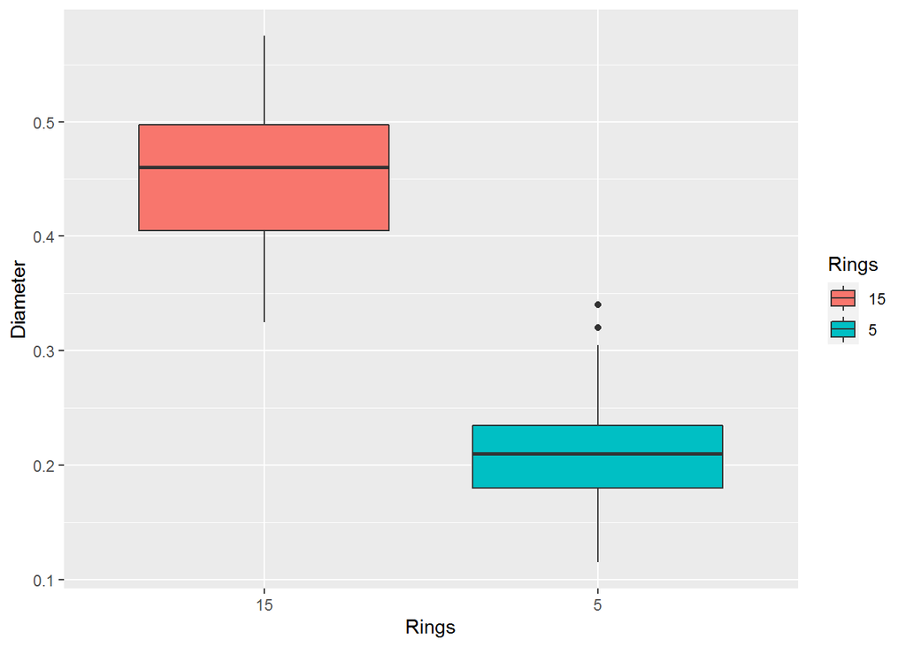

```r
q_5_15 <- shellfish_without_na %>%
  filter(Rings == 5 | Rings == 15)
ggplot(q_5_15, aes(Rings, Diameter, fill = Rings))+
  geom_boxplot()+
  scale_color_brewer(palette = 'Set1')
```

Судя по графику в среднем диаметр моллюсков с 5 кольцами меньше диаметра моллюсков с 15 кольцами. Проверим статистическую значимость полученных результатов. Для этого нужно убедиться в нормальности распределения данных. Это проверяется с помощью теста Шипиро-Уилка.

```r
shapiro.test(q_5_15[q_5_15$Rings == 5, 4])
```

```
##
##  Shapiro-Wilk normality test
##
## data:  q_5_15[q_5_15$Rings == 5, 4]
## W = 0.98192, p-value = 0.1269
```

```r
shapiro.test(q_5_15[q_5_15$Rings == 15, 4])
```

```
##
##  Shapiro-Wilk normality test
##
## data:  q_5_15[q_5_15$Rings == 15, 4]
## W = 0.98227, p-value = 0.1836
```

```r
ttest <- t.test(q_5_15[q_5_15$Rings == 5, 4], q_5_15[q_5_15$Rings == 15, 4])
```

Значение t-статистики составляет -33.52,p-value по результатам теста Стьюдента составляет 0, а значит, можно сделать вывод, что присутствуют статистически значимые различия между диаметром моллюсков с 5 и 15 кольцами.

# 10 Поиск возможной взаимосвязи переменных Diameter и Whole_weight

Наличие взаимосвязи можно проверить с помощью корреляционного теста. Выбор корелляционного теста зависит от нормальности распределения исследуемых признаков.

```r
shapiro.test(shellfish_without_na$Diameter)
```

```
##
##  Shapiro-Wilk normality test
##
## data:  shellfish_without_na$Diameter
## W = 0.97043, p-value < 2.2e-16
```

```r
shapiro.test(shellfish_without_na$Whole_weight)
```

```
##
##  Shapiro-Wilk normality test
##
## data:  shellfish_without_na$Whole_weight
## W = 0.97233, p-value < 2.2e-16
```

Переменные Diameter и Whole_weight распределены не нормально - значения p.value для Диаметра 0, N = 4156 и для Веса 0, N = 4156. Используем коэффициент корреляции Спирмена.

```r
cor <- cor.test(shellfish_without_na$Diameter, shellfish_without_na$Whole_weight, method = "spearman", exact = FALSE)
```

Уровень корелляции составляет 0.97(p-value 0). Значение коэффициента корреляции довольно велико и, таким образом, можно заключить, что между диаметром и весом моллюска присутствует сильная положительная корреляция. Как и в предыдущем задании построим график для визуализации. ВЗаимосвязь переменных нелинейна.

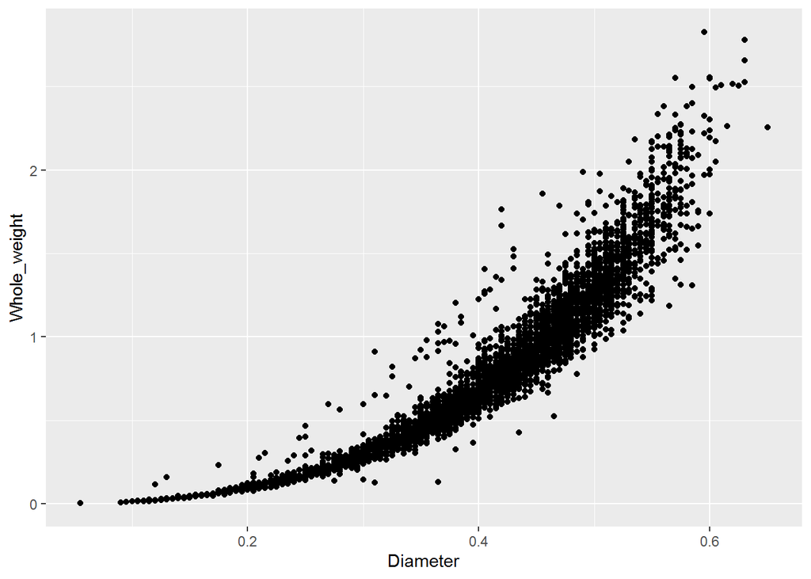

```r
ggplot(shellfish_without_na, aes(Diameter, Whole_weight)) +
  geom_point()
```